# Cotoneaster dummy analysis

Christiaan Petrus Gildenhuys

2026-03-30

## Overview

Hi Luke, I wrote this dummy analysis of Cotoneaster to demonstrate some ideas I have.

Last we spoke you showed me what you were doing with the native and invasive range data and I mentioned that we’ll have to exclude species with no invasive range from that analysis. However, on reflection I realised that this is not the case at all. You can independently model the zeros in the dataset (interpreted as the species not having an invasive range) alongside the native and invasive ranges using zero-inflated models (or in this case, hurdle models). (for simplicity I’m using the term invasion synonymous with naturalised/introduction/having non-native ranges for the purposes of this demonstration)

You also mentioned that including trait data would be ideal, so I included it here to demonstrate how trait data (or any other data) can be incorporated into the model.

Zero-inflated models (and hurdle models) essentially model the zeros in the dataset (the zero-inflated component) independently from the non-zeros in the data (the conditional component, i.e. conditional on the response not being a zero). It is basically combining a linear regression and a logistic regression. I think this approach could be very useful in the Cotoneaster case study as a zero invasive range is a proxy for introduction status and a non-zero is a proxy for “performance” (or similar concept) after introduction.

With this in mind you can do some hypothesis testing for example:

**H0:** The null hypothesis, i.e. no effect.

**H1:** There is a positive relationship between native range size and probability of being introduced/having an invasive range (the zero-inflated component)

**H2:** There is a positive relationship between native range size and invasive range size (given that the species is introduced)

**H3:** There is a positive relationship between trait X and probability of having an invasive range

**H4:** There is a positive relationship between trait X and extent of invasive range

etc.

## Generating dummy data

I asked ChatGPT to help me generate and analyse some dummy data for a zero inflated model of Cotoneaster native and invasive range sizes along with some trait data. Here is the code it came up with. Feel free to skip over this.

```r
set.seed(123)

n <- 130

# Predictors
native_area   <- rlnorm(n, meanlog = 10, sdlog = 0.5)   # large scale variation
fruit_diam    <- rnorm(n, mean = 2, sd = 0.5)           # cm
leaf_area     <- rlnorm(n, meanlog = 3, sdlog = 0.4)    # cm^2

# Standardize predictors (important for stability)
native_area_s <- scale(native_area)
fruit_diam_s  <- scale(fruit_diam)
leaf_area_s   <- scale(leaf_area)

# --- Zero inflation process (logistic) ---
# Probability of being NON-zero (i.e., invasive)
eta_zero <- 0.5 +
            1.2 * native_area_s +
            0.8 * fruit_diam_s -
            1.0 * leaf_area_s

prob_nonzero <- plogis(eta_zero)

is_nonzero <- rbinom(n, size = 1, prob = prob_nonzero)

# --- Continuous process (only for non-zero species) ---
mu <- 5 +
      2.0 * native_area_s +
      1.5 * fruit_diam_s -
      1.2 * leaf_area_s

invasive_area <- ifelse(
  is_nonzero == 1,
  rnorm(n, mean = mu, sd = 1),
  0
)

# Ensure no negative areas (truncate at zero)
invasive_area[invasive_area < 0] <- 0

# Combine into dataframe
dat <- data.frame(
  invasive_area,
  native_area,
  fruit_diam,
  leaf_area
)
```

## Analysing the data

In this section I analyse the data.

First I plot all the variables in the dataset. In this case the graph is quite busy but note the relationship between native and invasive ranges which is clearly zero inflated. It also looks like there might be some relationship with fruit diameter and invasive area (which of course there is because we are simulating the data) and potentially some relationship between leaf area as well.

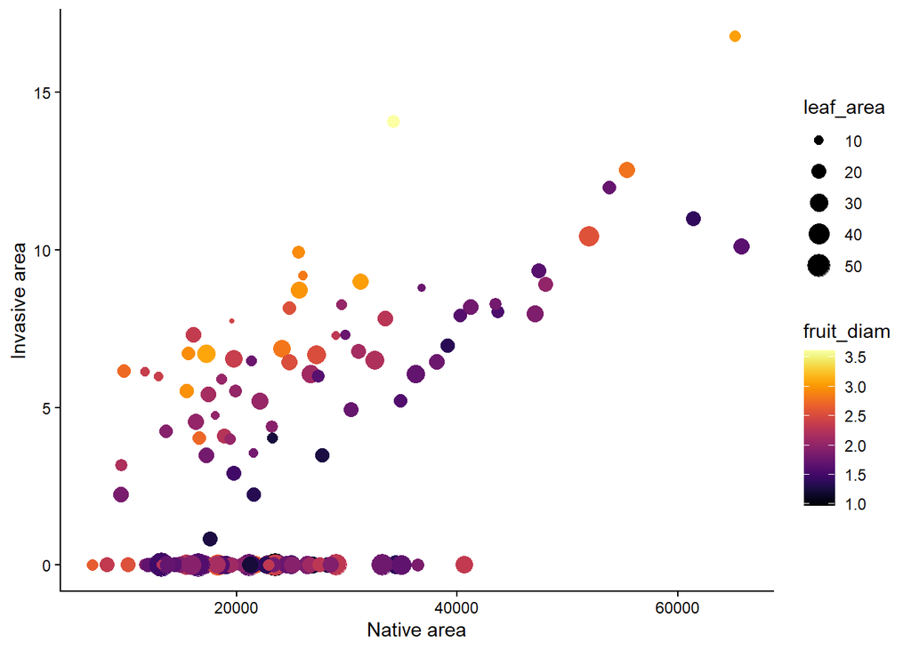

```r
dat%>%ggplot()+
  geom_point(aes(native_area,invasive_area,colour = fruit_diam,size = leaf_area))+
  scale_colour_continuous(palette = "Inferno")+
  ylab("Invasive area")+
  xlab("Native area")
```

**Figure 1:** Visualisation of the raw data. You can clearly see the zero inflation in the data.

## Building the model

Now let’s build our model.

```r
model<-glmmTMB(data = dat,
               formula = invasive_area ~ native_area + fruit_diam + leaf_area,
               ziformula = ~ native_area + fruit_diam + leaf_area,
               family = gaussian())
```

Here, I use the `glmmTMB` package which allows for the flexible incorporation of zero-inflated components. I’m using `invasive_area` as the response variable and `native_area`, `fruit_diam`, and `leaf_area` as predictor variables, all incorporating a binomial logit zero component and a Gaussian conditional component.

Of course, normally you would check for assumptions here but since the data are simulated we can of course say that our data meet all the required assumptions.

The model in this case explained a substantial amount of data with an adjusted R<sup>2</sup> value of 0.9284508.

Let’s see the summary table.

```r
summary(model)
```

```
##  Family: gaussian  ( identity )
## Formula:          invasive_area ~ native_area + fruit_diam + leaf_area
## Zero inflation:                 ~native_area + fruit_diam + leaf_area
## Data: dat
##
##       AIC       BIC    logLik -2*log(L)  df.resid
##     304.9     330.7    -143.4     286.9       121
##
##
## Dispersion estimate for gaussian family (sigma^2): 0.829
##
## Conditional model:
##               Estimate Std. Error z value Pr(>|z|)
## (Intercept) -3.406e+00  5.954e-01  -5.720 1.06e-08 ***
## native_area  1.806e-04  8.635e-06  20.912  < 2e-16 ***
## fruit_diam   3.168e+00  2.184e-01  14.504  < 2e-16 ***
## leaf_area   -9.333e-02  1.786e-02  -5.227 1.72e-07 ***
## ---
## Signif. codes:  0 '***' 0.001 '**' 0.01 '*' 0.05 '.' 0.1 ' ' 1
##
## Zero-inflation model:
##               Estimate Std. Error z value Pr(>|z|)
## (Intercept)  3.434e+00  1.427e+00   2.407 0.016093 *
## native_area -1.344e-04  3.166e-05  -4.245 2.19e-05 ***
## fruit_diam  -1.945e+00  5.517e-01  -3.525 0.000423 ***
## leaf_area    1.597e-01  3.558e-02   4.489 7.16e-06 ***
## ---
## Signif. codes:  0 '***' 0.001 '**' 0.01 '*' 0.05 '.' 0.1 ' ' 1
```

Let’s make it look nice.

```r
model%>%broom.mixed::tidy()%>%
  mutate(across(estimate:statistic, ~round(.,digits = 2)))%>%
  mutate(p.value = case_when(p.value < 0.001 ~ "< 0.001",
                             p.value < 0.01 ~ "< 0.01",
                             .default = paste("  ",round(p.value,digits = 3))))%>%
  flextable()%>%autofit()
```

| effect | component | term | estimate | std.error | statistic | p.value |
| --- | --- | --- | --- | --- | --- | --- |
| fixed | cond | (Intercept) | -3.41 | 0.60 | -5.72 | < 0.001 |
| fixed | cond | native_area | 0.00 | 0.00 | 20.91 | < 0.001 |
| fixed | cond | fruit_diam | 3.17 | 0.22 | 14.50 | < 0.001 |
| fixed | cond | leaf_area | -0.09 | 0.02 | -5.23 | < 0.001 |
| fixed | zi | (Intercept) | 3.43 | 1.43 | 2.41 | 0.016 |
| fixed | zi | native_area | 0.00 | 0.00 | -4.25 | < 0.001 |
| fixed | zi | fruit_diam | -1.94 | 0.55 | -3.53 | < 0.001 |
| fixed | zi | leaf_area | 0.16 | 0.04 | 4.49 | < 0.001 |

Of course everything is significant because we simulated it that way. This example would support all our hypotheses in the first section, but of course with real data you might find that a variable can be significant predictor for introduction into a new range but not for the extent of introduction. This can be interpreted as for example: “Native range sizes predict introduction of Cotoneaster species into novel ranges but not invasive range sizes which are more strongly predicted by trait X.”

## Visualising the model

Here I visualise the model do demonstrate what is going on under the hood.

Let’s start of with just the main effects (native and invasive areas). The following graphs show the marginal effect of native area on invasive area (i.e. all other predictors are averaged in the model predictions)

The graph below is visualising the continuous prediction with the original data.

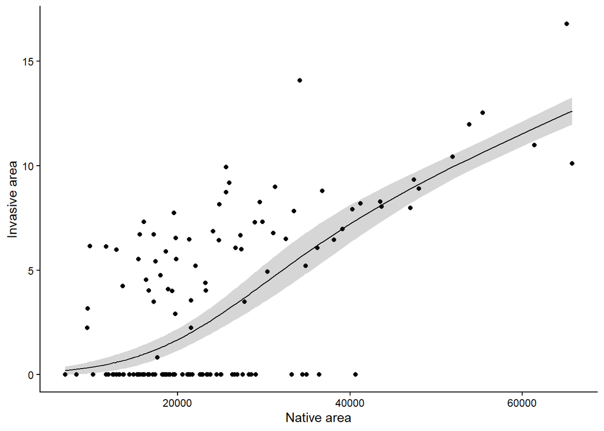

```r
newdata <- data.frame(
  invasive_area = dat$invasive_area,
  native_area = dat$native_area,
  fruit_diam = mean(dat$fruit_diam),
  leaf_area = mean(dat$leaf_area)
)

predictions(model,newdata = newdata,type = "response")%>%
  ggplot()+
  geom_point(aes(native_area,invasive_area))+
  geom_line(aes(native_area,estimate))+
  geom_ribbon(aes(x = native_area,
                  ymin = conf.low,
                  ymax = conf.high),alpha = 0.2)+
  ylab("Invasive area")+
  xlab("Native area")
```

**Figure 2:** This visualises the overall model fit. At lower levels of Native area, the model predicts high probability of no invasive range.

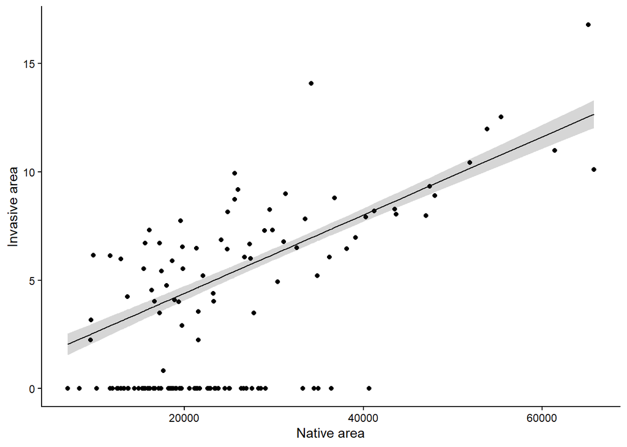

```r
predictions(model,newdata = newdata,type = "conditional")%>%
  ggplot()+
  geom_point(aes(native_area,invasive_area))+
  geom_line(aes(native_area,estimate))+
  geom_ribbon(aes(x = native_area,
                  ymin = conf.low,
                  ymax = conf.high),alpha = 0.2)+
  ylab("Invasive area")+
  xlab("Native area")
```

**Figure 3:** Here I visualise the effect of native area conditional (the conditional component) on the species having an invasive range, i.e. not zero. You can see that it is a linear relationship.

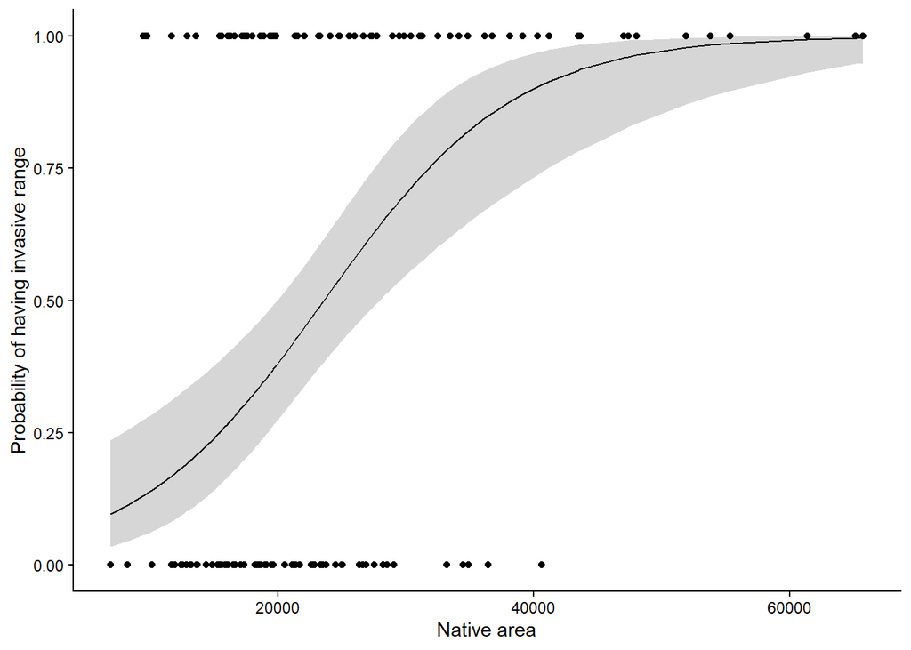

```r
predictions(model,newdata = newdata,type = "zlink")%>%
  mutate(across(c(estimate,conf.low,conf.high), ~1-plogis(.)),
         is_invasive = ifelse(invasive_area>0,1,0))%>%
  ggplot()+
  geom_point(aes(native_area,is_invasive))+
  geom_line(aes(native_area,estimate))+
  geom_ribbon(aes(x = native_area,ymin = conf.low,ymax = conf.high),alpha = 0.2)+
  ylab("Probability of having invasive range")+
  xlab("Native area")
```

**Figure 3:** Finally, this graph illustrates the zeros in the data, you can see that probability of the species having an invasive range increases with native area. I flipped the graph from the default settings to have the response be interpreted as “probability of having an invasive range”.

Of course, these visualisations can also be made for any other variables, for example:

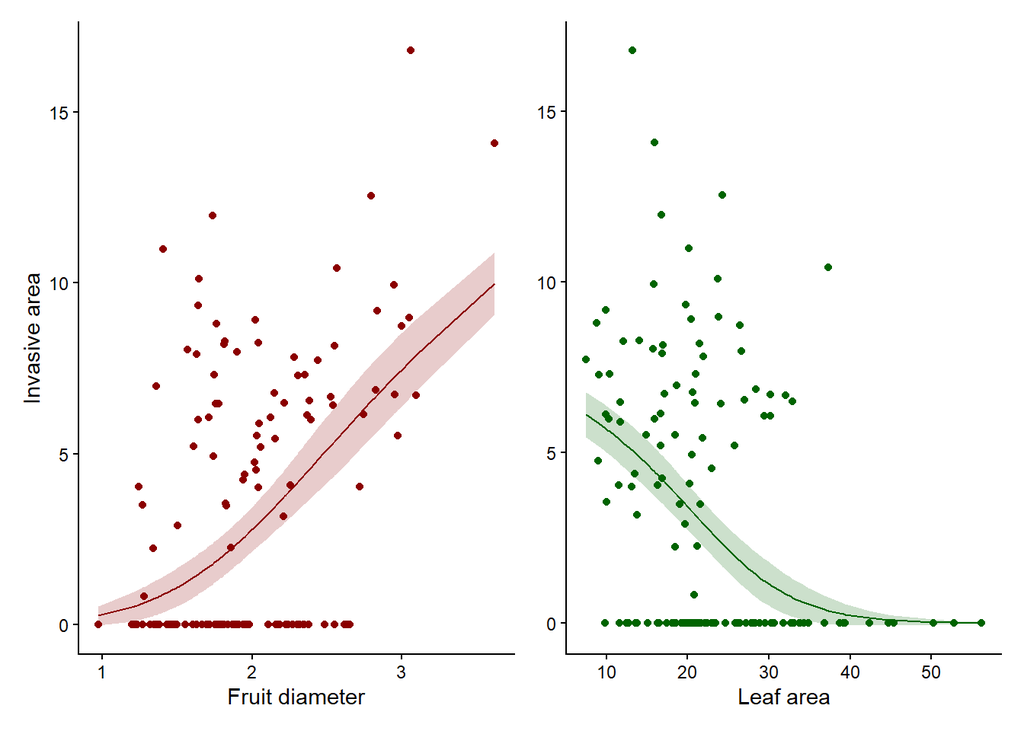

```r
newdata2 <- data.frame(
  invasive_area = dat$invasive_area,
  native_area = mean(dat$native_area),
  fruit_diam = dat$fruit_diam,
  leaf_area = mean(dat$leaf_area)
)
newdata3 <- data.frame(
  invasive_area = dat$invasive_area,
  native_area = mean(dat$native_area),
  fruit_diam = mean(dat$fruit_diam),
  leaf_area = dat$leaf_area
)

predictions(model,newdata = newdata2,type = "response")%>%
  #cbind(dat)%>%view()
  ggplot()+
  geom_point(aes(fruit_diam,invasive_area),colour = "darkred")+
  geom_line(aes(fruit_diam,estimate),colour = "darkred")+
  geom_ribbon(aes(x = fruit_diam,
                  ymin = conf.low,
                  ymax = conf.high),alpha = 0.2,fill = "darkred")+
  ylab("Invasive area")+
  xlab("Fruit diameter")+


predictions(model,newdata = newdata3,type = "response")%>%
  #cbind(dat)%>%view()
  ggplot()+
  geom_point(aes(leaf_area,invasive_area),colour = "darkgreen")+
  geom_line(aes(leaf_area,estimate),colour = "darkgreen")+
  geom_ribbon(aes(x = leaf_area,
                  ymin = conf.low,
                  ymax = conf.high),alpha = 0.2,fill = "darkgreen")+
  ylab(element_blank())+
  xlab("Leaf area")
```

**Figure 4:** Marginal response curves for fruit diameter and leaf area.

## Final thoughts

I think this is a pretty interesting and novel approach (I had a quick look through some literature and I haven’t found much with this exact approach in invasion science).

How practical would it be to collect trait information or some other variable for all ~130 species? Of course, we could also just use the range sizes alone or use other variables. What do you think?

For the method of estimating range size, I have my reservations about using grid cells for various reasons I won’t get into here. I was thinking about looking into using polygons to estimate range sizes. I’ll try it out and let you know how it goes.

Otherwise, I’ll send you more progress about the maps and things soon!

Cheers Chris